# Autoregressive Moving Average Process

Time Series

Description for Autoregressive Moving Average Process

Yeongeun Jeon , Jung In Seo  
2024-01-13

- **참고 : Statistics and Data Analysis for Financial Engineering**

# **1. 함수 설명**

- 관측된 시계열에 자기회귀이동평균모형(Autoregressive Moving Average Model)을 구축하는 데 유용한 함수를 요약하면 다음과 같다.

| 함수 | 설명 |
| --- | --- |
| `arima()` | ARMA모형의 차수 $p$와 $q$를 지정하여 모형 구축 |
| `auto.arima()` | 모형의 차수 지정없이 자동적으로 최적화된 모형 구축 |
| `acf()` | 상관도표그림 |
| `pacf()` | 부분상관도표그림 |
| `Box.test()` | Ljung-Box Test |
| `checkresiduals()` | 잔차가 백색잡음과정의 가정을 만족하는지 확인할 때 사용 |
| `forecast()` | 예측 |

# **2. 예제**

## **2-1. BMW 데이터셋**

- Package `"evir"`에서 제공하는 BMW 데이터셋은 1973년 1월부터 1996년 7월 사이에 BMW 주식의 일별 로그 수익률에 대한 시계열 데이터셋이다.

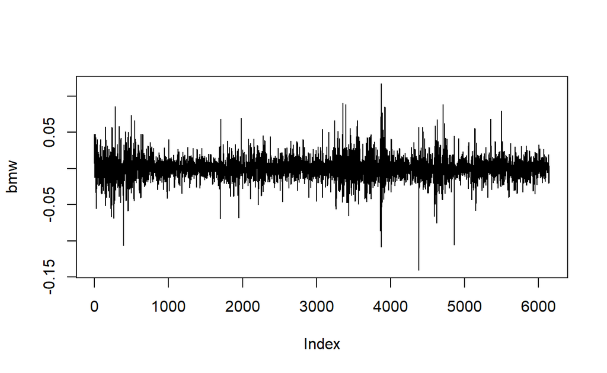

```r
# 패키지 설치
pacman::p_load("evir")

# 데이터 불러오기
data(bmw, package = "evir")

# 시계열 그림
plot(bmw, type = "l")
```

`Result!` 증가하거나 감소하는 추세가 없어서 시간의 흐름에 따라 평균이 일정하다.

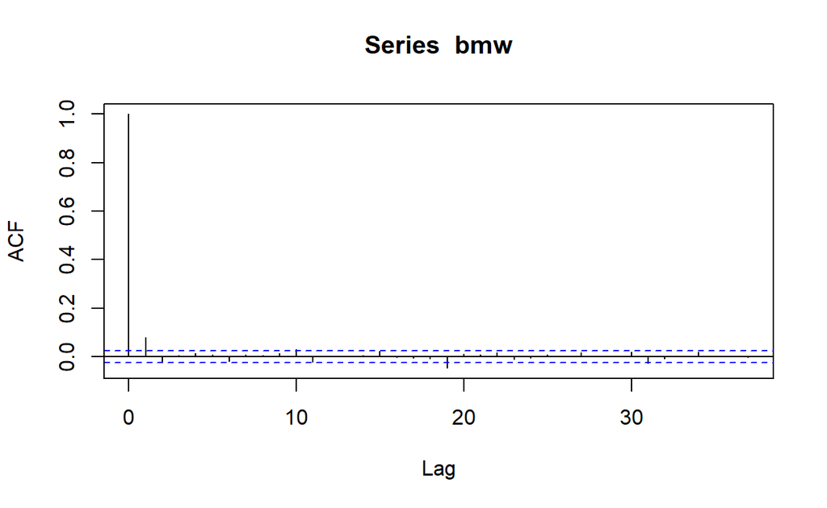

```r
# 상관도표그림
acf(bmw)
```

`Result!` 시차 1에서 막대의 끝이 파란색 선을 넘어가므로 시차 1에 대해 유의한 자기상관관계가 존재한다.

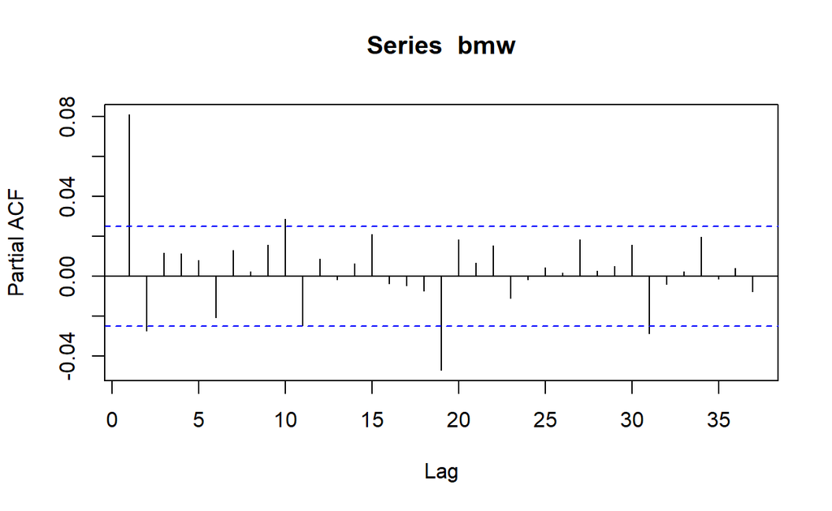

```r
# 부분상관도표그림
pacf(bmw)
```

`Result!` 시차 1에서 막대의 끝이 파란색 선을 넘어가므로 시차 1에 대해 유의한 부분자기상관관계가 존재한다.  
`Caution!` 큰 시차에서의 막대 끝이 파란색 선을 넘어가는 것은 우연 변동에 의한 가능성이 높다.

```r
# Ljung-Box Test
Box.test(bmw, lag = 5,
         type = "Ljung-Box")
```

```
    Box-Ljung test

data:  bmw
X-squared = 44.987, df = 5, p-value = 1.46e-08
```

`Result!` 귀무가설 $H_0 : \rho(1)=\rho(2)=\cdots=\rho(5)=0$에 대한 검정 결과에 따르면, $p$값이 0에 가까우므로 유의수준 0.05에서 귀무가설을 기각한다. 즉, 관측된 시계열에 대해 $\rho(1), \rho(2),\cdots,\rho(5)$ 중 유의한 자기상관관계가 적어도 1개 존재한다.

```r
# Fit ARMA(1,1)
ARMA.bmw <- arima(bmw,
                  order = c(1, 0, 1))
```

`Caution!` 함수 `arima()`를 이용하여 ARMA(1,1) 모형을 구축하려면 옵션 `order = c(1, 0, 1)`을 입력한다. 만약, ARMA($p,q$) 모형을 구축하려면 옵션 `order = c(p, 0, q)`을 입력하면 된다.

```r
# 모형 추정 결과
print(ARMA.bmw)
```

```
Call:
arima(x = bmw, order = c(1, 0, 1))

Coefficients:
          ar1     ma1  intercept
      -0.2278  0.3122      4e-04
s.e.   0.1380  0.1349      2e-04

sigma^2 estimated as 0.0002161:  log likelihood = 17214.87,  aic = -34421.74
```

`Result!` 출력 결과를 요약하면 다음과 같다.  
1. 모수의 추정치는 $\hat{\mu}=0.0004$, $\hat{\phi}=-0.2278$, $\hat{\theta}=0.3122$, $\hat{\sigma}^2_\epsilon = 0.0002161$이다. 이를 이용하면 관측된 시계열에 대해 구축된 ARMA(1,1) 모형은 $Y_t-0.0004 = -0.2278(Y_{t-1}-0.0004)+ \epsilon_t + 0.3122\epsilon_{t-1}$이다.

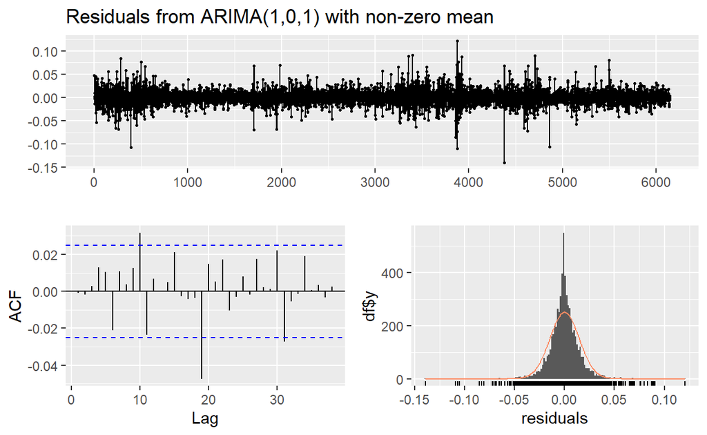

```
    Ljung-Box test

data:  Residuals from ARIMA(1,0,1) with non-zero mean
Q* = 12.394, df = 8, p-value = 0.1345

Model df: 2.   Total lags used: 10
```

```r
# 잔차를 이용한 백색잡음과정 체크
pacman::p_load("forecast")

checkresiduals(ARMA.bmw)
```

`Caution!` Package `"forecast"`의 함수 `checkresiduals()`를 이용하여 잔차에 대한 모형 진단을 수행할 수 있다.  
`Result!` 출력 그래프를 보면, 첫 번째 그래프는 잔차가 추세를 가지는지, 등분산성을 만족하는지 알 수 있다. ACF 그래프를 통해서는 잔차가 자기상관관계를 가지는지 알 수 있으며, 히스토그램을 통해 잔차가 좌우대칭 종 모양의 정규분포를 따르는지 알 수 있다.  
“Ljung-Box” 검정 결과에 따르면, 귀무가설 $H_0 : \rho(1)=\rho(2)=\cdots=\rho(10)=0$에 대해 $p$값이 0.1345이므로 유의수준 0.05에서 $p$값이 0.05보다 크기 때문에 귀무가설을 기각하지 못한다. 즉, 잔차에 대해 시차 10까지의 자기상관계수 $\rho(1), \rho(2), \cdots, \rho(10)$ 중 유의한 자기상관계수가 적어도 1개 존재한다는 증거가 부족하며, 해당 시계열에 대해 ARMA(1,1) 모형을 가정하는 것이 적절하다.

## **2-2. Mishkin 데이터셋**

- Package `"Ecdat"`에서 제공하는 Mishkin 데이터셋은 1950년 2월부터 1990년 12월 사이에 인플레이션율에 대한 시계열 데이터셋이다.

```r
# 패키지 설치
pacman::p_load("Ecdat")

# 데이터 불러오기
data(Mishkin, package = "Ecdat")
y = as.vector(Mishkin[,1])             # 월별 인플레이션율 추출
y
```

```
  [1] -3.552289  5.247540  1.692860  5.064298  6.719322 11.668920
  [7]  9.912501  8.346786  6.517766  4.865085 16.076321 19.154240
 [13] 14.061910  4.650814  1.546310  4.627010 -1.540355  1.540355
 [19]  0.000000  7.672257  6.102576  6.209472  4.533152  0.000000
 [25] -7.564866  0.000000 19.570490 -1.494151  1.494151  0.000000
 [31] -1.494151  0.000000  1.494151  0.000000 -1.494151 -2.993894
 [37] -6.010291  3.008908  1.501630  2.997634  4.482457  2.979029
 [43]  2.971549  1.483071  2.960655 -4.443726 -1.484906  2.967978
 [49] -1.483071 -1.484906 -2.839906  2.839906  1.484906  0.000000
 [55] -1.484906 -2.839906 -2.982291  2.982291 -2.982291  0.000000
 [61]  0.000000  1.492020  0.000000  0.000000  0.000000  2.978693
 [67] -2.978693  4.330177  0.000000  1.484906 -2.836390  0.000000
 [73]  0.000000  2.836390  1.483071  5.914023  5.751562  8.774637
 [79] -1.457907  1.457907  5.682521  1.449363  2.893485  0.000000
 [85]  2.886525  2.748830  2.873018  2.866156  7.006195  5.678584
```

[output cut: 67 more lines]

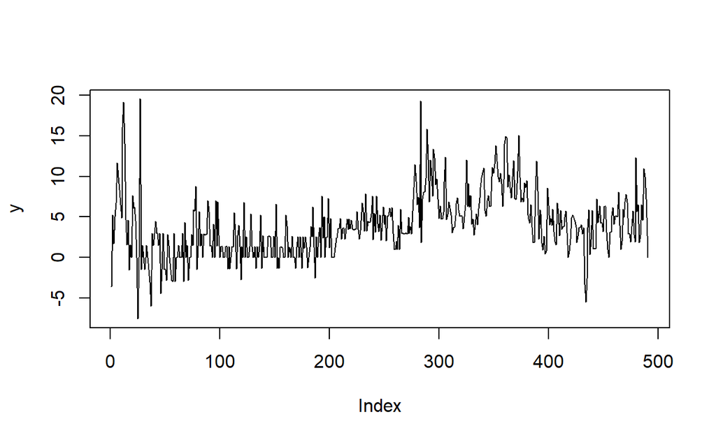

```r
# 시계열 그림
plot(y, type = "l")
```

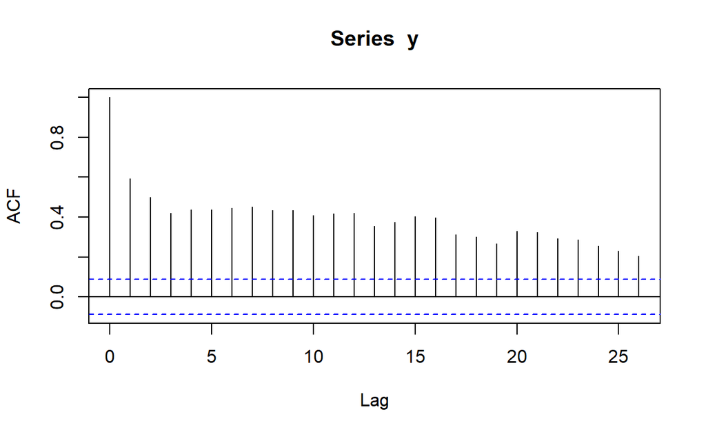

```r
# 상관도표그림
acf(y)
```

`Result!` 대부분의 시차에서 막대의 끝이 파란색 선을 넘어가므로 시차 25까지 유의한 자기상관관계가 존재한다.

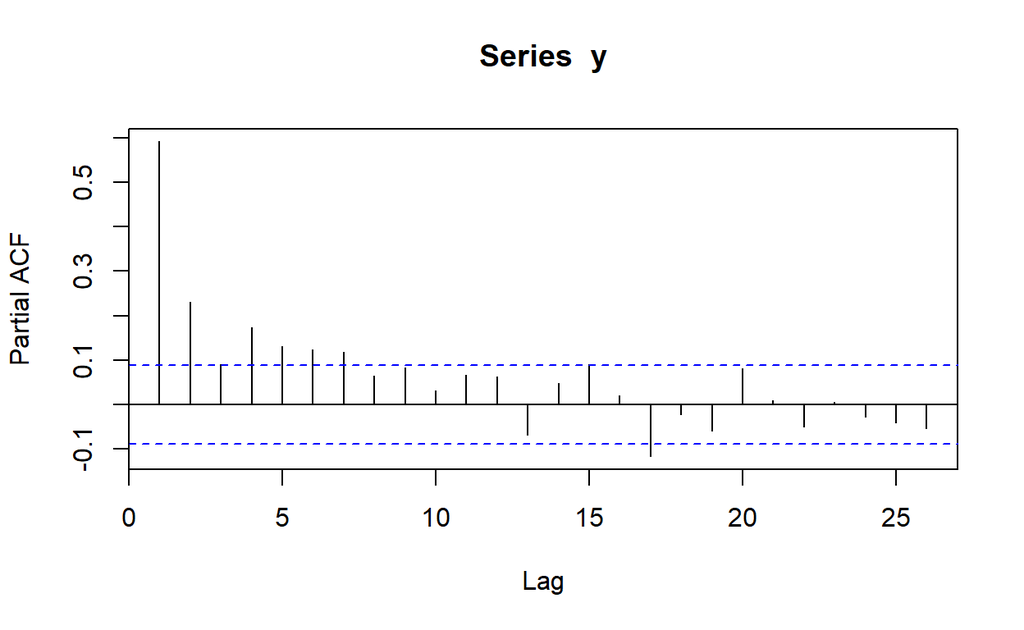

```r
# 부분상관도표그림
pacf(y)
```

`Result!` 시차 7까지 막대의 끝이 파란색 선을 넘어가므로 시차 7까지 유의한 부분자기상관관계가 존재한다.

```r
# Ljung-Box Test
Box.test(y, lag = 7,
         type = "Ljung-Box")
```

```
    Box-Ljung test

data:  y
X-squared = 774.34, df = 7, p-value < 2.2e-16
```

`Result!` 귀무가설 $H_0 : \rho(1)=\rho(2)=\cdots=\rho(7)=0$에 대한 검정 결과에 따르면, $p$값이 0에 가까우므로 유의수준 0.05에서 귀무가설을 기각한다. 즉, 관측된 시계열에 대해 $\rho(1), \rho(2),\cdots,\rho(7)$ 중 유의한 자기상관관계가 적어도 1개 존재한다.

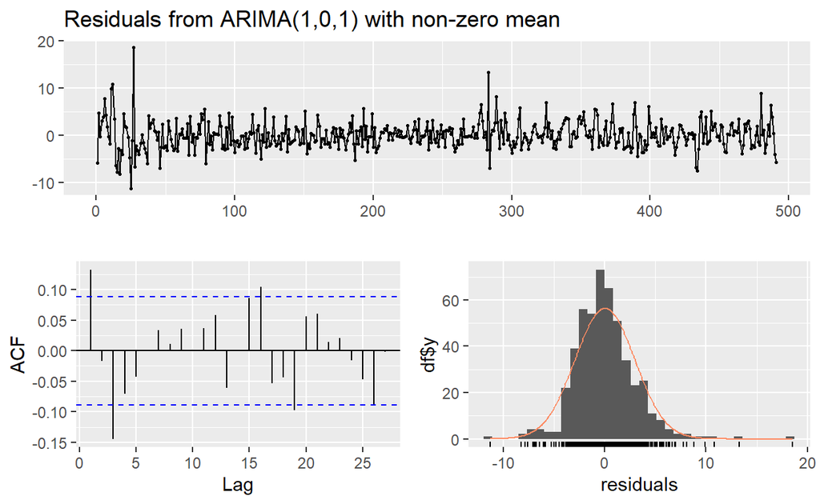

```
    Ljung-Box test

data:  Residuals from ARIMA(1,0,1) with non-zero mean
Q* = 23.724, df = 8, p-value = 0.002549

Model df: 2.   Total lags used: 10
```

```r
# Fit ARMA(1,1)
ARMA.y <- arima(y,
                order = c(1, 0, 1))

# 잔차를 이용한 백색잡음과정 체크
checkresiduals(ARMA.y)
```

`Caution!` Package `"forecast"`에서 제공하는 함수 `auto.arima()`에 옵션 `max.p = 20, max.q = 20, d = 0`을 입력하여 최적의 ARMA($p,q$) 모형을 찾을 수 있다.

```r
pacman::p_load("forecast")

auto.y2 <- auto.arima(y, max.p = 20,
                      max.q = 20, d = 0,
                      ic = "aic")           # AIC 기준으로 AIC가 가장 작은 모형을 최적 모형으로 선택

print(auto.y2)
```

```
Series: y
ARIMA(2,0,1) with non-zero mean

Coefficients:
         ar1      ar2      ma1    mean
      1.2074  -0.2237  -0.8573  4.1068
s.e.  0.0587   0.0551   0.0337  1.0692

sigma^2 = 8.533:  log likelihood = -1221.52
AIC=2453.03   AICc=2453.16   BIC=2474.02
```

`Result!` 관측된 시계열에 대해 AIC를 기준으로 최적의 모형은 ARMA(2,1) 모형이다. 모수 추정 결과에 따르면, $\hat{\mu} = 4.1068$, $\hat{\phi}_1=1.2074$, $\hat{\phi}_2=-0.2237$, $\hat{\theta}=-0.8573$, $\hat{\sigma}^2_\epsilon = 8.533$이다. 이를 이용하면 관측된 시계열에 대해 구축된 ARMA(2,1) 모형은 $Y_t-4.1068 = 1.2074(Y_{t-1}-4.1068)-0.2237(Y_{t-2}-4.1068)+\epsilon_t -0.8573\epsilon_{t-1}$이다.

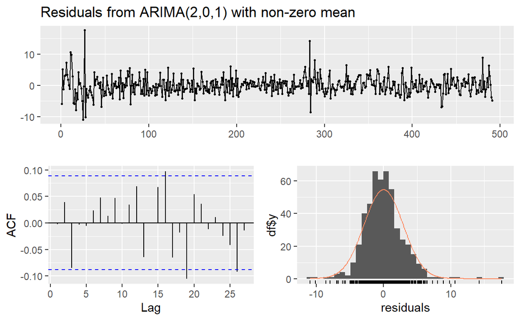

```
    Ljung-Box test

data:  Residuals from ARIMA(2,0,1) with non-zero mean
Q* = 6.9828, df = 7, p-value = 0.4307

Model df: 3.   Total lags used: 10
```

```r
# 잔차를 이용한 백색잡음과정 체크
checkresiduals(auto.y2)
```